# 03: Random Walk Model

## Model Evaluation

### Out-Of-Sample Error

```r
sales_naive_model %>%
  forecast(
    h = h_length
  ) %>%
  accuracy(
    df_test
  ) %>%
  filter(
    is.finite(MAPE)
  ) %>%
  arrange(
    desc(MAPE)
  ) %>%
  datatable()
```

|  | .model | family | store_nbr | .type | ME | RMSE | MAE | MPE | MAPE | MASE | RMSSE | ACF1 |
| --- | --- | --- | --- | --- | --- | --- | --- | --- | --- | --- | --- | --- |
| 1 | Naive Model | HOME AND KITCHEN II | 48 | Test | -472.4375 | 479.1596158901541 | 472.4375 | -1706.208534080205 | 1706.208534080205 |  |  | -0.02531686489774159 |
| 2 | Naive Model | HOME AND KITCHEN II | 35 | Test | -65.0625 | 65.10616330271658 | 65.0625 | -1584.665178571429 | 1584.665178571429 |  |  | 0.3277920962199312 |
| 3 | Naive Model | BEAUTY | 28 | Test | -11.8125 | 11.92424001771182 | 11.8125 | -590.625 | 590.625 |  |  | -0.2835972017673049 |
| 4 | Naive Model | GROCERY II | 41 | Test | -151.3125 | 152.3677705421983 | 151.3125 | -492.4771441972894 | 492.4771441972894 |  |  | 0.2177310486475944 |
| 5 | Naive Model | GROCERY II | 35 | Test | -15.875 | 16.42026187367303 | 15.875 | -488.9575441919192 | 488.9575441919192 |  |  | 0.1450199645075421 |
| 6 | Naive Model | LADIESWEAR | 45 | Test | -55.125 | 56.77697596737607 | 55.125 | -476.4563252369163 | 476.4563252369163 |  |  | 0.4467025188065252 |
| 7 | Naive Model | AUTOMOTIVE | 27 | Test | -14 | 14.60308186651023 | 14 | -411.4583333333333 | 411.4583333333333 |  |  | 0.1304347826086956 |
| 8 | Naive Model | SEAFOOD | 21 | Test | -14.75 | 15.21101574517626 | 14.75 | -406.7357397504456 | 406.7357397504456 |  |  | -0.1145361990950226 |
| 9 | Naive Model | CELEBRATION | 13 | Test | -14.125 | 15.10380746699322 | 14.125 | -384.0799172232996 | 384.0799172232996 |  |  | -0.2051133260513381 |
| 10 | Naive Model | CLEANING | 38 | Test | -3236.625 | 3242.725686054866 | 3236.625 | -376.2536106204964 | 376.2536106204964 |  |  | 0.3932310432389934 |

[output cut: 1422 more lines]

The forecasts for `HOME AND KITCHEN II` sales in stores 48 and 35 seem particularly egregious.

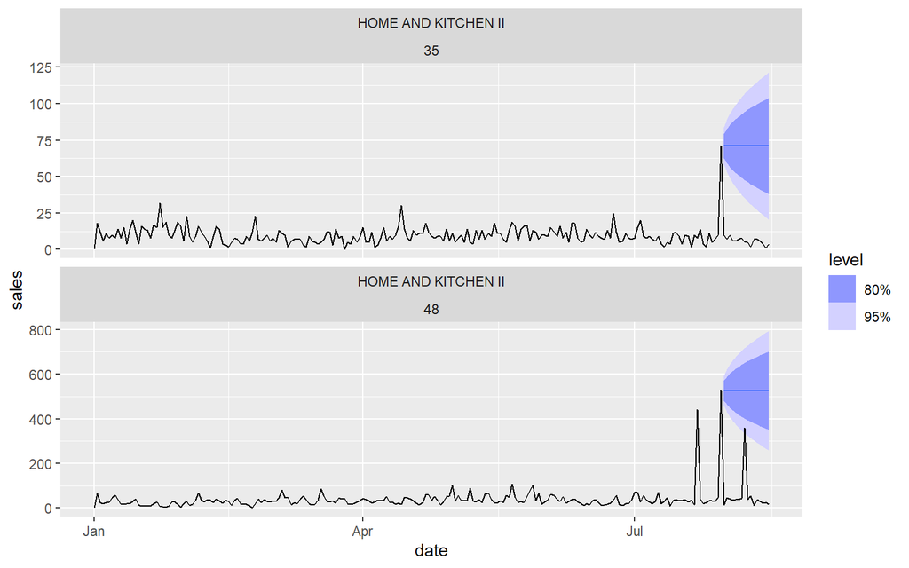

```r
sales_naive_model %>%
  filter(
    family == "HOME AND KITCHEN II",
    store_nbr %in% c(35, 48)
  ) %>%
  forecast(
    h = h_length
  ) %>%
  autoplot(
    df %>%
      filter(
        family == "HOME AND KITCHEN II",
        store_nbr %in% c(35, 48),
        date >= "2017-01-01"
      )
  )
```

The last observation in the training data for these two time series is an anomalous spike, leading to a severe overestimation.

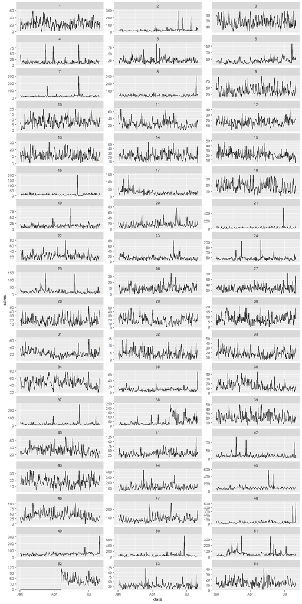

```r
df_train %>%
  filter(
    date >= "2017-01-01",
    family == "HOME AND KITCHEN II"
  ) %>%
  ggplot(aes(date, sales)) +
  geom_line() +
  facet_wrap(~store_nbr, ncol = 3, scales = "free_y")
```

### Residual Diagnostics

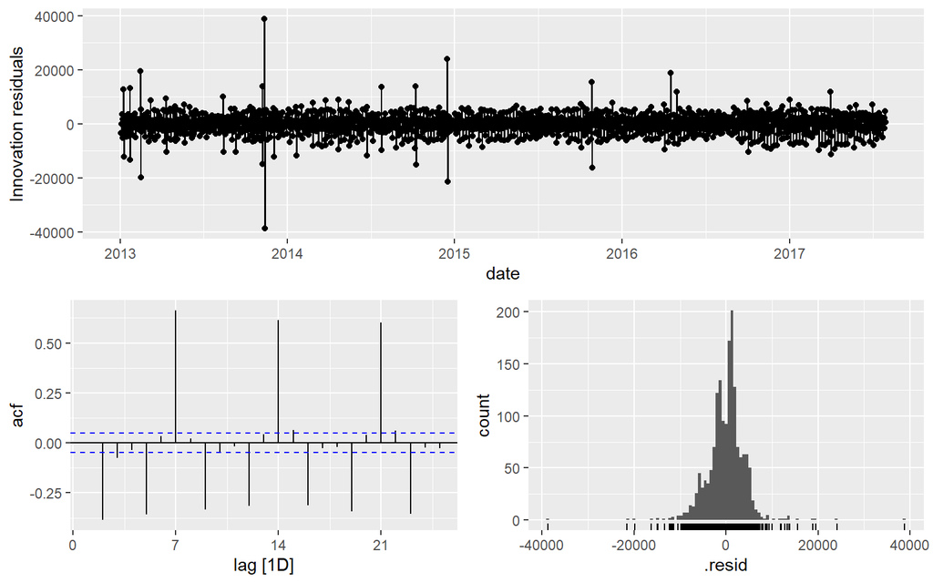

```r
sales_naive_model %>%
  filter(
    family == "GROCERY I",
    store_nbr == 44
  ) %>%
  gg_tsresiduals()
```

The residuals don’t exhibit any autocorrelation of lag 1, indicating that the residuals are not trended. However, we see systemic spikes in the autocorrelation plot at lags 7, 14, and 21, indicating a very strong weekly seasonal pattern.

## Model Score

We can estimate how our model scores w.r.t. to the evaluation criterion by computing the RMSLE on the holdout set:

```r
sales_naive_forecast <- sales_naive_model %>%
  forecast(
    h = h_length
  ) %>%
  as_tibble() %>%
  select(
    family,
    store_nbr,
    date,
    forecast = .mean
  )

sales_naive_forecast
```

```
## # A tibble: 28,512 × 4
##    family     store_nbr date       forecast
##    <chr>          <dbl> <date>        <dbl>
##  1 AUTOMOTIVE         1 2017-07-31        1
##  2 AUTOMOTIVE         1 2017-08-01        1
##  3 AUTOMOTIVE         1 2017-08-02        1
##  4 AUTOMOTIVE         1 2017-08-03        1
##  5 AUTOMOTIVE         1 2017-08-04        1
##  6 AUTOMOTIVE         1 2017-08-05        1
##  7 AUTOMOTIVE         1 2017-08-06        1
##  8 AUTOMOTIVE         1 2017-08-07        1
##  9 AUTOMOTIVE         1 2017-08-08        1
## 10 AUTOMOTIVE         1 2017-08-09        1
## # ℹ 28,502 more rows
```

```r
df_test %>%
  as_tibble() %>%
  left_join(
    sales_naive_forecast
    ,
    by = c("date", "family", "store_nbr")
  ) %>%
  rmsle(
    actuals = "sales",
    forecast = "forecast"
  )
```

```
## # A tibble: 1 × 1
##   rmsle
##   <dbl>
## 1 0.659
```